# Bicycle Sharing Service Case Study

Nicholas Chovancek

2022-12-09

## Overview

Cyclistic is a fictional bicycle-sharing service in a major metropolitan city in the United States. They operate over 5,800 bicycles that are interchanged at more than 600 docking stations. Customers can check a bicycle from one docking station and return it to any other station at any time. Cyclistic features several types of bicycles, including electric bicycles. Customers can either pay for their trips on a per-ride basis (denoted as casual users) or subscribe to an annual membership (denoted as members). The financial analysis team has determined that annual members are more profitable than casual users, which prompted the marketing manager to set a goal of converting as many casual users to annual members as possible.

## Business Task

Based on the scenario, the business task is to analyze ridership data from Cyclistic to understand the differences in riding behavior between casual riders and annual members. This information will inform a marketing strategy aimed at converting casual users to members.

## Data Sources

Data for this case study was provided by Lyft Bikes and Scooters’ Divvy Bike sharing program with the following [license](https://ride.divvybikes.com/data-license-agreement). The associated data can be found at this [link](https://divvy-tripdata.s3.amazonaws.com/index.html). For the project, the most recent 12 months of ridership data were used, which at the time of writing was December 2021-November 2022.

## Data Cleaning and Manipulation

Each month of the time period in question was represented in a standalone .csv file. After all 12 files were read into R Studio Desktop as data frames and checked for consistency. Once all files were confirmed to be consistent, bind_rows() was used to compile 12 data frames into one.

Previous versions of these data sets had labeled annual members as “subscribers” and casual users as “Customers”. The following code was run to ensure that the *member_casual* field was consistent.

```r
all_trips<- all_trips %>%
  mutate(member_casual=recode(member_casual,
                              "Subscriber"="member",
                              "Customer"="casual"))
table(all_trips$member_casual)
```

```
##
##  casual  member
## 2346876 3386575
```

New columns were generated from the *started_at* field to facilitate more efficient sorting and grouping on date objects. The new columns are *date*, *month*, *day*, *year*, and *day_of_week*.

```r
all_trips$date<-as.Date(all_trips$started_at)
all_trips$month<- format(as.Date(all_trips$date), "%m")
all_trips$day<- format(as.Date(all_trips$date), "%d")
all_trips$year<- format(as.Date(all_trips$date), "%Y")
all_trips$day_of_week<- format(as.Date(all_trips$date), "%A")
```

Create a column *ride_length* based on a difference in time between the end and beginning of a ride. *ride_length* is then converted to numeric type to allow for calculations.

```r
all_trips$ride_length<-difftime(all_trips$ended_at, all_trips$started_at)

str(all_trips)
```

```
## tibble [5,733,451 × 19] (S3: tbl_df/tbl/data.frame)
##  $ ride_id           : chr [1:5733451] "46F8167220E4431F" "73A77762838B32FD" "4CF42452054F59C5" "3278BA87BF698339" ...
##  $ rideable_type     : chr [1:5733451] "electric_bike" "electric_bike" "electric_bike" "classic_bike" ...
##  $ started_at        : POSIXct[1:5733451], format: "2021-12-07 15:06:07" "2021-12-11 03:43:29" ...
##  $ ended_at          : POSIXct[1:5733451], format: "2021-12-07 15:13:42" "2021-12-11 04:10:23" ...
##  $ start_station_name: chr [1:5733451] "Laflin St & Cullerton St" "LaSalle Dr & Huron St" "Halsted St & North Branch St" "Halsted St & North Branch St" ...
##  $ start_station_id  : chr [1:5733451] "13307" "KP1705001026" "KA1504000117" "KA1504000117" ...
##  $ end_station_name  : chr [1:5733451] "Morgan St & Polk St" "Clarendon Ave & Leland Ave" "Broadway & Barry Ave" "LaSalle Dr & Huron St" ...
##  $ end_station_id    : chr [1:5733451] "TA1307000130" "TA1307000119" "13137" "KP1705001026" ...
##  $ start_lat         : num [1:5733451] 41.9 41.9 41.9 41.9 41.9 ...
##  $ start_lng         : num [1:5733451] -87.7 -87.6 -87.6 -87.6 -87.7 ...
##  $ end_lat           : num [1:5733451] 41.9 42 41.9 41.9 41.9 ...
##  $ end_lng           : num [1:5733451] -87.7 -87.7 -87.6 -87.6 -87.6 ...
##  $ member_casual     : chr [1:5733451] "member" "casual" "member" "member" ...
##  $ date              : Date[1:5733451], format: "2021-12-07" "2021-12-11" ...
##  $ month             : chr [1:5733451] "12" "12" "12" "12" ...
##  $ day               : chr [1:5733451] "07" "11" "15" "26" ...
##  $ year              : chr [1:5733451] "2021" "2021" "2021" "2021" ...
##  $ day_of_week       : chr [1:5733451] "Tuesday" "Saturday" "Wednesday" "Sunday" ...
##  $ ride_length       : 'difftime' num [1:5733451] 455 1614 766 883 ...
##   ..- attr(*, "units")= chr "secs"
```

```r
all_trips$ride_length<-as.numeric(as.character(all_trips$ride_length))
is.numeric(all_trips$ride_length)
```

```
## [1] TRUE
```

The scenario noted that entries exist in the data set where bicycles were removed for service or have negative ride duration. A new data frame was created without these entries and NA’s were dropped.

```r
all_trips_v2<-all_trips[!(all_trips$start_station_name=="HQ QR" | all_trips$ride_length<0),]
all_trips_v2<-drop_na(all_trips_v2)
```

## Analysis

```r
summary((all_trips_v2$ride_length)/60)
```

```
##     Min.  1st Qu.   Median     Mean  3rd Qu.     Max.
##     0.00     6.07    10.62    17.16    19.05 34354.07
```

```r
aggregate(all_trips_v2$ride_length ~ all_trips_v2$member_casual, FUN=mean)
```

```
##   all_trips_v2$member_casual all_trips_v2$ride_length
## 1                     casual                1450.6486
## 2                     member                 746.8384
```

```r
aggregate(all_trips_v2$ride_length ~ all_trips_v2$member_casual, FUN=median)
```

```
##   all_trips_v2$member_casual all_trips_v2$ride_length
## 1                     casual                      835
## 2                     member                      539
```

```r
aggregate(all_trips_v2$ride_length ~ all_trips_v2$member_casual, FUN=max)
```

```
##   all_trips_v2$member_casual all_trips_v2$ride_length
## 1                     casual                  2061244
## 2                     member                    89594
```

```r
aggregate(all_trips_v2$ride_length ~ all_trips_v2$member_casual, FUN=min)
```

```
##   all_trips_v2$member_casual all_trips_v2$ride_length
## 1                     casual                        0
## 2                     member                        0
```

To see the average ride length for both casual riders and members per day of the week, the code below was entered. Care was taken to order the days of the week for readability.

```r
all_trips_v2$day_of_week<- ordered(all_trips_v2$day_of_week, levels=c("Sunday",
        "Monday", "Tuesday", "Wednesday", "Thursday", "Friday", "Saturday"))
all_trips_v2 %>% aggregate(ride_length/60 ~ member_casual + day_of_week, FUN=mean)
```

```
##    member_casual day_of_week ride_length/60
## 1         casual      Sunday       27.45494
## 2         member      Sunday       13.85629
## 3         casual      Monday       24.95502
## 4         member      Monday       12.02760
## 5         casual     Tuesday       21.69092
## 6         member     Tuesday       11.79493
## 7         casual   Wednesday       21.00808
## 8         member   Wednesday       11.81330
## 9         casual    Thursday       21.69145
## 10        member    Thursday       12.04016
## 11        casual      Friday       22.48541
## 12        member      Friday       12.21304
## 13        casual    Saturday       26.84982
## 14        member    Saturday       14.00632
```

To analyze ridership data by type and weekday, riders were grouped by type and day of the week. Then, their number of rides and mean ride length was calculated.

```r
all_trips_v2 %>%
  mutate(weekday=wday(started_at, label=TRUE)) %>%
  group_by(member_casual, weekday) %>%
  summarize(number_of_rides=n(), average_duration=mean(ride_length)) %>%
  arrange(member_casual, weekday)
```

```
## # A tibble: 14 × 4
## # Groups:   member_casual [2]
##    member_casual weekday number_of_rides average_duration
##    <chr>         <ord>             <int>            <dbl>
##  1 casual        Sun              303095            1647.
##  2 casual        Mon              212247            1497.
##  3 casual        Tue              196152            1301.
##  4 casual        Wed              206294            1260.
##  5 casual        Thu              232314            1301.
##  6 casual        Fri              252150            1349.
##  7 casual        Sat              369469            1611.
##  8 member        Sun              299858             831.
##  9 member        Mon              377634             722.
## 10 member        Tue              410872             708.
## 11 member        Wed              422758             709.
## 12 member        Thu              421139             722.
## 13 member        Fri              366676             733.
## 14 member        Sat              339601             840.
```

## Key Findings and Visualizations

The scenario explained that a significant percentage of users are members who utilize Cyclistic to commute to work. The bar chart below supports that claim by showing that the number of members using Cyclistic during the work week is high compared to the number of casual users. Conversely, members take fewer rides on weekends while the number of casual riders increased. With more detailed riding data and customer surveys, the number of members commuting to work could be approximated to get a more accurate look at the purpose behind these rides. To increase casual to member conversions, one strategy could be to highlight customer use cases and demonstrate how many people use the service for work, showing that it is viable and convincing others to do the same.

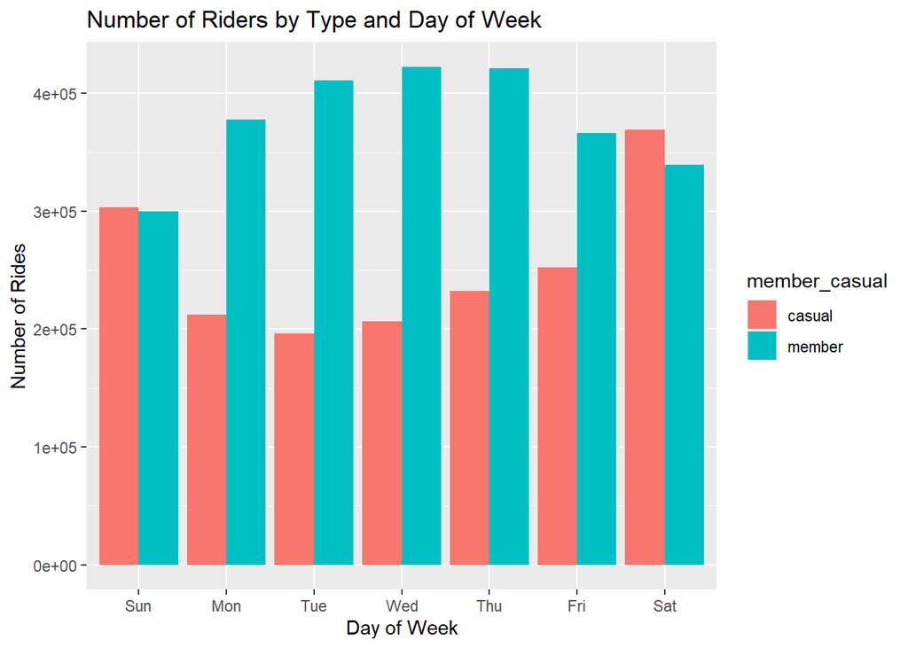

```r
all_trips_v2 %>%
  mutate(weekday=wday(started_at, label=TRUE)) %>%
  group_by(member_casual, weekday) %>%
  summarize(number_of_rides=n(), average_duration=mean(ride_length)) %>%
  arrange(member_casual, weekday) %>%
  ggplot(aes(x=weekday, y=number_of_rides, fill=member_casual)) +
  geom_col(position='dodge')+ labs(title="Number of Riders by Type and Day of Week", x="Day of Week", y="Number of Rides")
```

The next visualization further supports the claim that many members using Cyclistic during the work week are commuting. During the work week, member ride duration is almost totally consistent with minimal variation. Members also have slightly longer average trip duration on weekends. Casual users, however, take significantly longer trips overall, and on weekends the mean ride duration is almost twice as long as member ride duration. This suggests that many casual users are using the service for leisure or exercise. Assuming Cyclistic charges casual riders based on how long they have the bicycle, another marketing strategy could be to advertise a break-even point for casual riders where if they became an annual member, they would actually save money after using the service for x minutes.

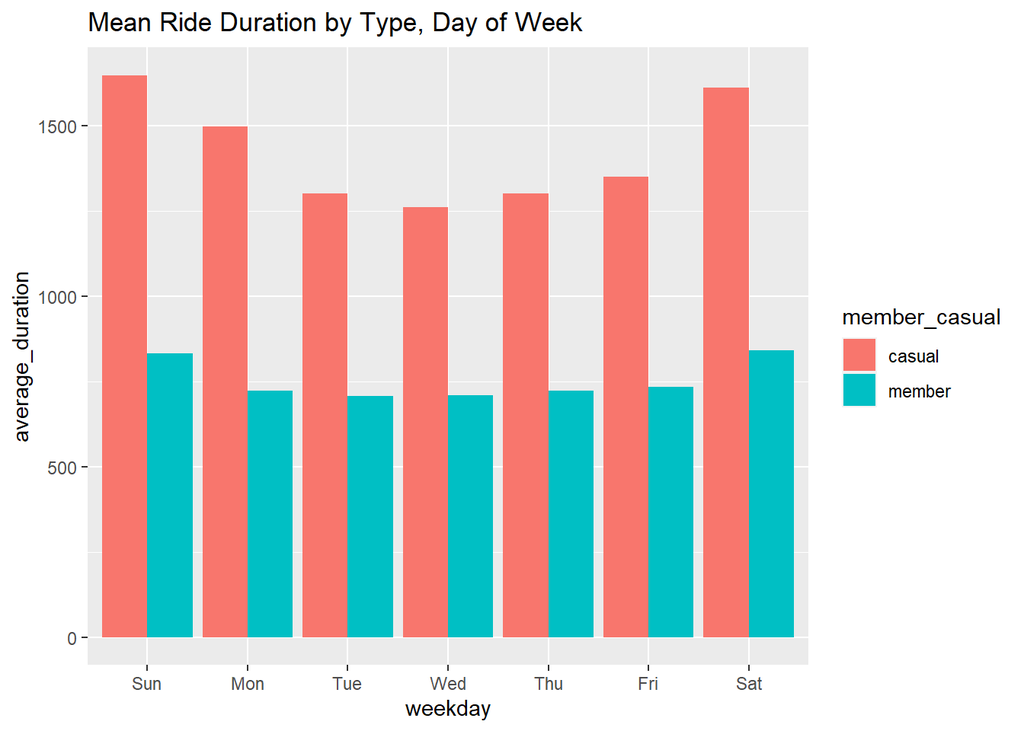

```r
all_trips_v2 %>%
  mutate(weekday=wday(started_at, label=TRUE)) %>%
  group_by(member_casual, weekday) %>%
  summarize(number_of_rides=n(), average_duration=mean(ride_length)) %>%
  arrange(member_casual, weekday) %>%
  ggplot(aes(x=weekday, y=average_duration, fill=member_casual))+
  geom_col(position='dodge')+labs(title="Mean Ride Duration by Type, Day of Week")
```

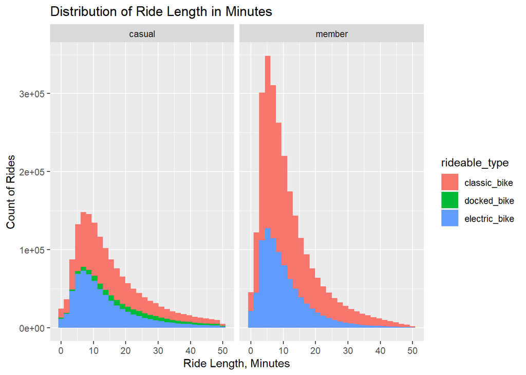

```r
hist_data<-all_trips_v2[!(all_trips_v2$ride_length>3000),]
hist_data<- drop_na(hist_data)
ggplot(data=hist_data)+geom_histogram(mapping=aes(ride_length/60, fill=rideable_type))+
  facet_wrap(~member_casual)+labs(title="Distribution of Ride Length in Minutes",
                                  x="Ride Length, Minutes", y="Count of Rides")
```

## Summary and Recommendations

Cyclistic has a robust network of bike sharing docks and a good customer base. Based on the data available, I make the following recommendations to help convert casual users to annual members: *Highlight customers who use the service to commute to work, demonstrating that it is a viable and cost-effective strategy for commuting* Advertise the break-even point where casual customers would save money by becoming annual members (i.e. if you ride more than __ minutes per month, you could save with an annual membership) *Given the distribution of ride duration, advertise how far the average rider could get in the city from a location in 20min using Cyclystic bikes and highlight the expansive dock network* Ensure that sufficient bikes are on hand during peak commute times to ensure Cyclystic commuting is feasible